# The Titanic Dataset Data Exploration

## Preliminary Wrangling

Dataset: https://www.kaggle.com/c/titanic/data

The sinking of the Titanic is one of the most infamous shipwrecks in history.

## The factors that Influence the Survivial of passenger from Titanic Ship Accident

### Investigation Overview

In this investigation, I'm most interested in figuring out what features are best for predicting the sirvival of the person in the titanic ship wreck dataset.

In this challenge, I'll try to answers the question: “what sorts of people were more likely to survive?” using passenger data (ie fare, age, gender, socio-economic class, etc).

### Visualising the survival of passenger (Passenger Survived)

Note: survived (0 = No; 1 = Yes) that's Zero (0) denote died and One (1) represent survived.

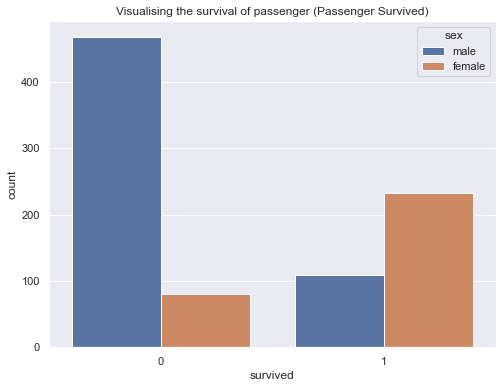

### Titanic passenger class (pclass)

The percentage in the above plot show the number of passenger subscribe to each of the three classes in the ship. As majority passenger are in the 3rd class, which also doubles the percentage of the two classes.

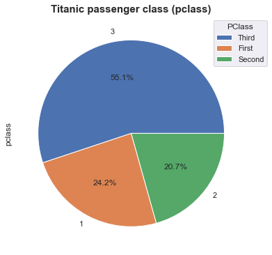

### Sex(Gender) vs. Survival

From the left, we can see that **468** male passengers didnot survived the accident only **109** were lucky to survived. Whereas **233** women survived the accident and **81** female died.

From the right,the totall number of observation from the dataset is **891** and **577** were men, and **314** are women. This number includes both adults and children.

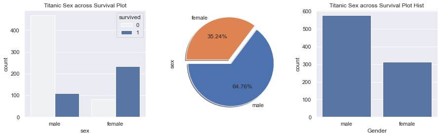